# Submission Spatial Upscaling

Patricia Helpap

2023-11-30

Setup:

```r
library(tidyverse)
library(ggplot2)
library(lattice)
library(caret)
library(recipes)
library(ranger)
library(ggpubr)

#Load the data directly from online source:
df <- readr::read_csv("https://raw.githubusercontent.com/stineb/leafnp_data/main/data/leafnp_tian_et_al.csv")
```

**Data:** We will work with a limited subset of the variables available in the file, and with the data aggregated by sites (identified by their respective longitudes and latitudes):

- leafN: leaf nitrogen content, in mass-based concentration units (gN/gDM)
- lon: longitude in decimal degrees east
- lat: latitude in decimal degrees north
- elv: Elevation above sea level (m)
- mat: mean annual temperature (degrees Celsius)
- map: mean annual precipitation (mm/yr)
- ndep: atmospheric nitrogen deposition (g/m^2 yr)
- mai: mean annual daily irradiance (µmol/m^2 s)
- Species: species name of the plant on which leaf N was measured

```r
common_species <- df |>
  group_by(Species) |>
  summarise(count = n()) |>
  arrange(desc(count)) |>
  slice(1:50) |>
  pull(Species)

dfs <- df |>
  dplyr::select(leafN, lon, lat, elv, mat, map, ndep, mai, Species) |>
  filter(Species %in% common_species)
  # group_by(lon, lat) |>
  # summarise(across(where(is.numeric), mean))
```

# Exercise results

## 1.1 Literature - *Ludwig et al. 2023*

*Explain the difference between random cross-validation and spatial cross-validation:*

From Ludwig et al, 2023: Random cross-validation uses randomly split data and only indicates the ability of the model to make predictions within the splits. Spatial cross-validation however holds back spatial units for validation and assess the ability of model predictions beyond the training data.

*Alternative to measuring distance for evaluation of spatial upscaling based on environmental covariates:*

Instead of calculating a dissimilarity index in terms of geographical distance, one could calculate it based on the environmental features and therefore determine the prediction skill as the area of applicability based on environmental data. The Area of Applicability would therefore be referring to feature space rather than geographical space. This could be a more sensible measure for evaluating spatial upscaling, as modeled environmental parameters such as leaf nitrogen are highly dependent on environmental conditions, not just geographical location.

## 1.2 Random cross validation

Use Random Forest to perform a 5-fold cross-validation with the leaf N data (leafN) and the following predictors:

- elv: Elevation above sea level (m)
- mat: mean annual temperature (degrees Celsius)
- map: mean annual precipitation (mm/yr)
- ndep: atmospheric nitrogen deposition (g/m^2 yr)
- mai: mean annual daily irradiance (µmol/m^2 s)
- Species: species name of the plant on which leaf N was measured

*Report the mean RMSE and R across cross-validation folds. Chose hyperparameters as mtry = 3 and min.node.size = 12 and others as their default in ranger::ranger().*

```r
#select the predictors we want;
df_rf <- df |>
  dplyr::select(leafN, elv, mat, map, ndep, mai, Species) |>
  filter(Species %in% common_species)

# Data splitting
set.seed(123)  # for reproducibility
split <- rsample::initial_split(df_rf, prop = 0.7, strata = "leafN")
ddf_train <- rsample::training(split)
ddf_test <- rsample::testing(split)

# The same model formulation is in the previous chapter
pp <- recipes::recipe(leafN ~ elv + mat + map + ndep + mai + Species,
                      data = ddf_train) |>
  recipes::step_center(recipes::all_numeric(), -recipes::all_outcomes()) |>
  recipes::step_scale(recipes::all_numeric(), -recipes::all_outcomes())

mod <- train( #random forest model
  pp,
  data = ddf_train %>%
    drop_na(),
  method = "ranger",
  trControl = trainControl(method = "cv", number = 5, savePredictions = "final"),
  tuneGrid = expand.grid( .mtry = floor(9 / 3),
                          .min.node.size = 12,
                          .splitrule = "variance"),
  metric = "RMSE",
  replace = FALSE,
  seed = 1982                # for reproducibility
)

# return RMSE and Rsquared:
cat("The Random Forest model was trained with hyperparameters mtry = ", mod$results$mtry, "and min.node.size = ", mod$results$min.node.size, ".",
  "\nThe RMSE value is:", mod$results$RMSE,
    "\nThe Rsquared value is:", mod$results$Rsquared)
```

```
## The Random Forest model was trained with hyperparameters mtry =  3 and min.node.size =  12 .
## The RMSE value is: 2.368301
## The Rsquared value is: 0.7849508
```

## 1.3 Spatial cross-validation

We first want to look at the spatial distribution of the data:

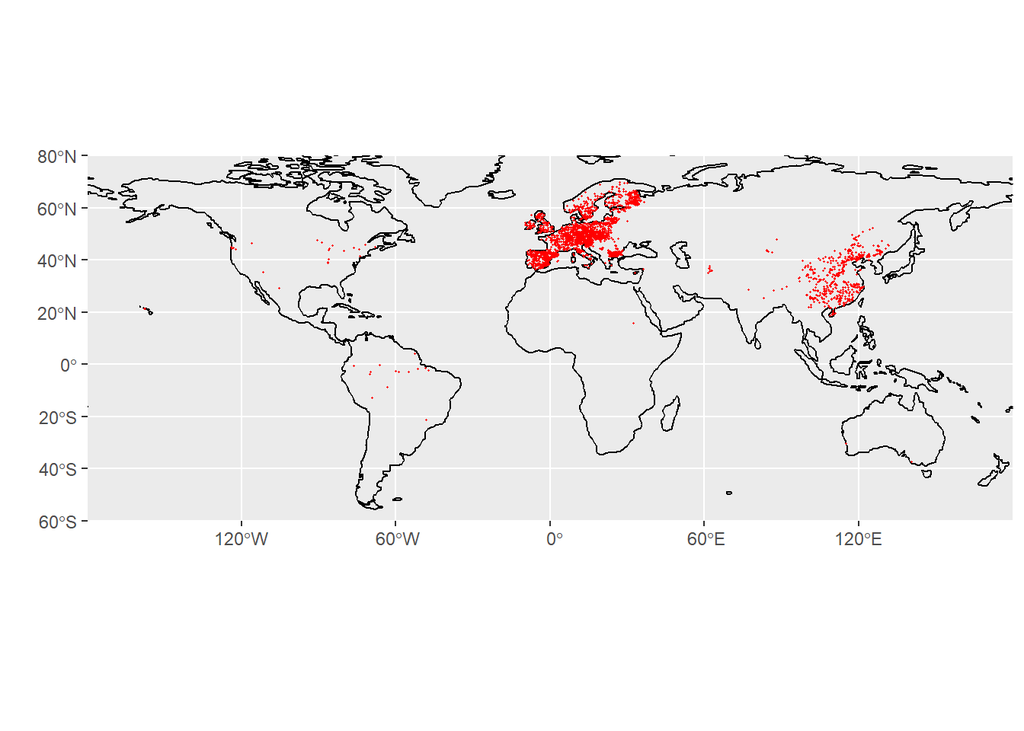

Fig. 1: Global spatial distribution of environmental data.

*1) Implications of geographical data distribution:*

The data are very heterogeneously distributed around the globe with a strong bias on central Europe and another cluster of data in eastern Asia. Only a couple of datapoints are recorded for the Americas, Africa and Oceania. As also mentioned in Ludwig et al., 2023, this will potentially bias the model results with higher accuracy for in regions with data clusters as there might be regions too dissimilar from the training data. In terms of model results, this could lead to spatial overfitting.

*2) Spatial cross-validation using k-means (k=5) and plotting it:*

```r
# cluster the data
set.seed(132) #for reproducibility
clusters <- kmeans(
  dfs[,2:3],
  centers = 5
)

dfs$clusters <- as.factor(clusters$cluster)
```

The calculated clusters can be visualised in a plot:

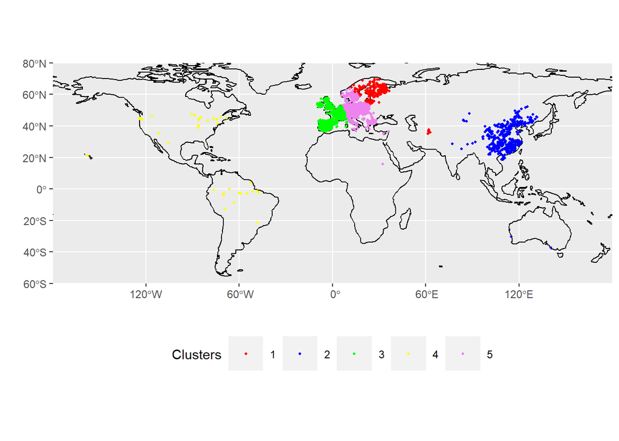

Fig. 2: Global spatial distribution of environmental data by clusters.

**3) Now, we want to visualise the distribution of ‘leafN’ by cluster:**

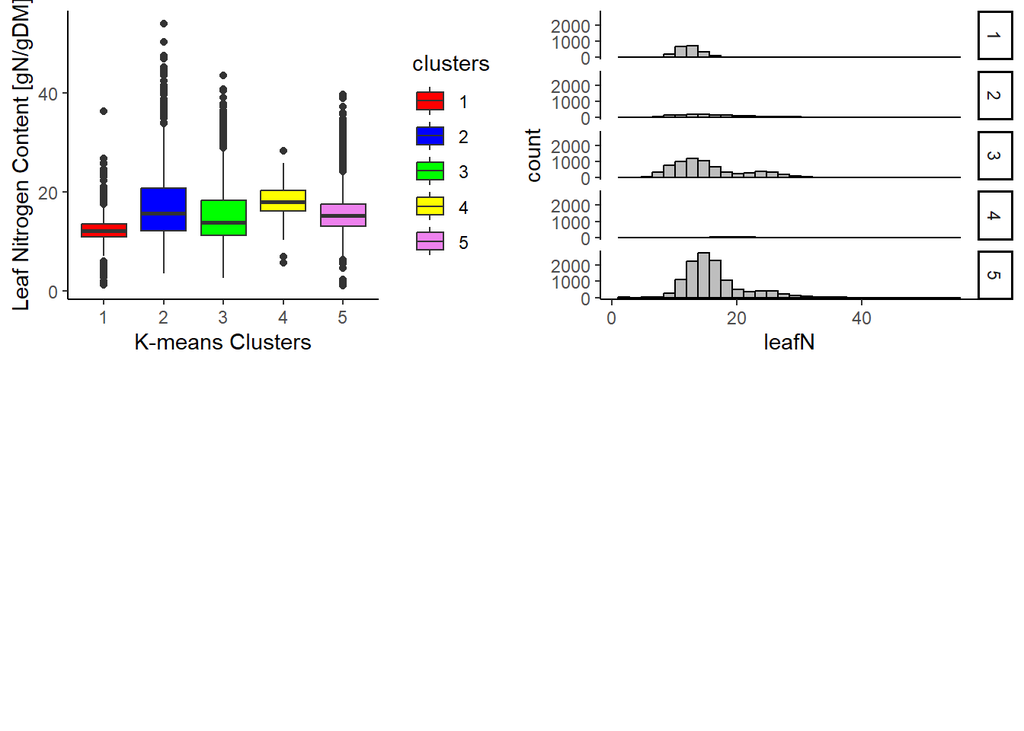

Fig. 3: Distribution of leafN data by spatial cluster.

*4) Random forest model for the identified clusters:*

Using a pre-defined grouping for delineating the folds in k-fold cross-validation can be done by first determining the indexes of rows for each group (a list of vectors that contain the row indexes of the training data). This can be done by:

```r
# create folds based on clusters

group_folds_train <- purrr::map(
  seq(length(unique(dfs$clusters))),
  ~ {
    dfs |>
      select(clusters) |>
      mutate(idx = 1:n()) |>
      filter(clusters != .) |>
      pull(idx)
  }
)

group_folds_test <- purrr::map(
  seq(length(unique(dfs$clusters))),
  ~ {
    dfs |>
      select(clusters) |>
      mutate(idx = 1:n()) |>
      filter(clusters == .) |>
      pull(idx)
  }
)
```

Then, implement the custom cross-validation “by hand”.

```r
# create a function that trains a random forest model on a given set of rows and
# predicts on a disjunct set of rows
train_test_by_fold <- function(df, idx_train, idx_val){

  mod <- ranger::ranger(
    x =  df[idx_train,2:9],  # data frame with columns corresponding to predictors
    y =  df$leafN[idx_train]   # a vector of the target values (not a data frame!)
  )

  pred <- predict(mod,       # the fitted model object
                  data = df[idx_val,2:9] # a data frame with columns corresponding to predictors
                  )

  rsq <- summary(lm(pred$predictions ~ df$leafN[idx_val] ))$r.squared # the R-squared determined on the validation set
  rmse <- sqrt(mean((df$leafN[idx_val] - pred$predictions)^2)) # the root mean square error on the validation set

  return(tibble(rsq = rsq, rmse = rmse))
}

# apply function on each custom fold and collect validation results in a nice
# data frame
out <- purrr::map2_dfr(
  group_folds_train,
  group_folds_test,
  ~train_test_by_fold(dfs,.x,.y)
) |>
  mutate(test_fold = 1:5)

out
```

```
## # A tibble: 5 × 3
##      rsq  rmse test_fold
##    <dbl> <dbl>     <int>
## 1 0.222   2.33         1
## 2 0.0138  7.04         2
## 3 0.569   4.19         3
## 4 0.174   3.61         4
## 5 0.516   3.22         5
```

*5) Result comparison and discussion:*

The performance of the two cross-validation methods (random & spatial) implemented above can be assessed via metrics such as the RMSE (the lower the rsme, the more accurate the predictions) and the R2-value, which assesses the goodness of model fit.

From the **random cross validation** we get results of *RMSE = 2.368301, Rsquared = 0.7849508*.

The **spatial cross validation** gives us 5 different results from the 5 folds / clusters used. Overall, the Rsqared values are lower than for Random CV and the RMSE is higher (see output table above). Differences in Rsquared and RSME are due to differences in the spatial clusters but also due to the frequency of observations in the folds. The histogram in Fig. 3 shows that the frequency of observations differs from fold to fold, which would also explains some variability in the Rsquared values. Low Rsquared values suggest model overfitting and poor model generalizability *(Ludwig et al., 2023)*.

The random cross validation therefore generates a better model than the spatial cross validation, with a higher Rsquared and lower RMSE value overall. As we saw in Fig. 1, the data is very strongly spatially biased. This spatial data-gap in predictors will therefore lead to weaker spatial predictions where no reference data is available. Since spatial cross-validation tests the ability of the model to predict unknown geographic locations whereas random cross-validation only indicates the ability of the model to make prediction within the cluster *(Ludwig et al., 2023)*, the random forest model naturally outperforms spatial cross validation here as the data is strongly spatially biased.

## 2.4 Environmental Cross-Validation

*1) perform a custom cross-validation as above, but this time considering five clusters of points not in geographical space, but in environmental space - spanned by the mean annual precipitation and the mean annual temperature. Report the R-squared and the RMSE on the validation set of each of the five folds.*

```r
# cluster the data
set.seed(42) #for reproducibility
env.clusters <- kmeans(
  dfs[,5:6], #mean annual precip & mean annual temp
  centers = 5
)

dfs$env.clusters <- as.factor(env.clusters$cluster)
```

**Plot the distribution of the clusters:**

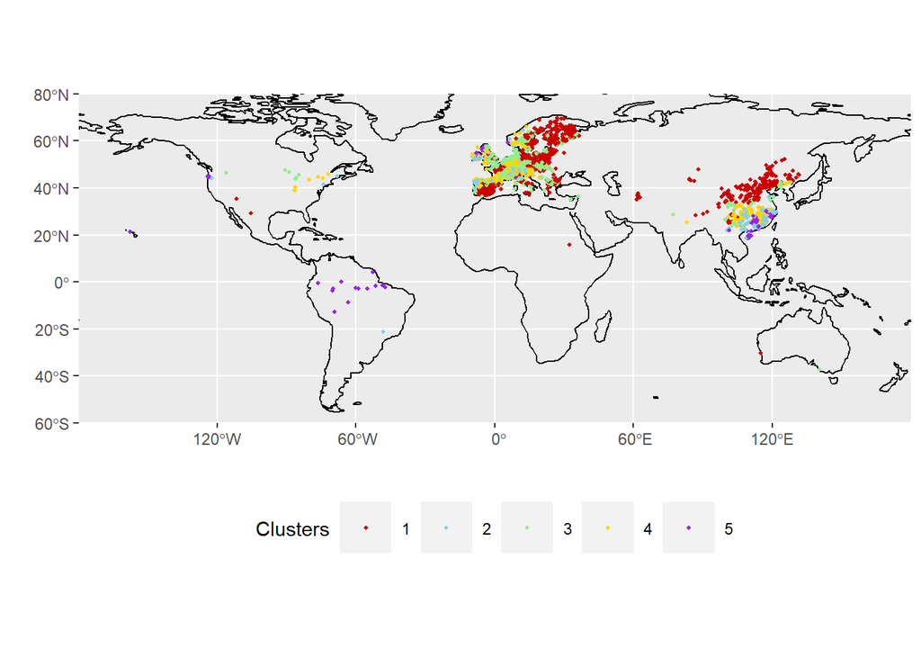

Fig. 4: Global spatial distribution of environmental data by clusters.

**The distribution of leafN by environmental clusters visualised:**

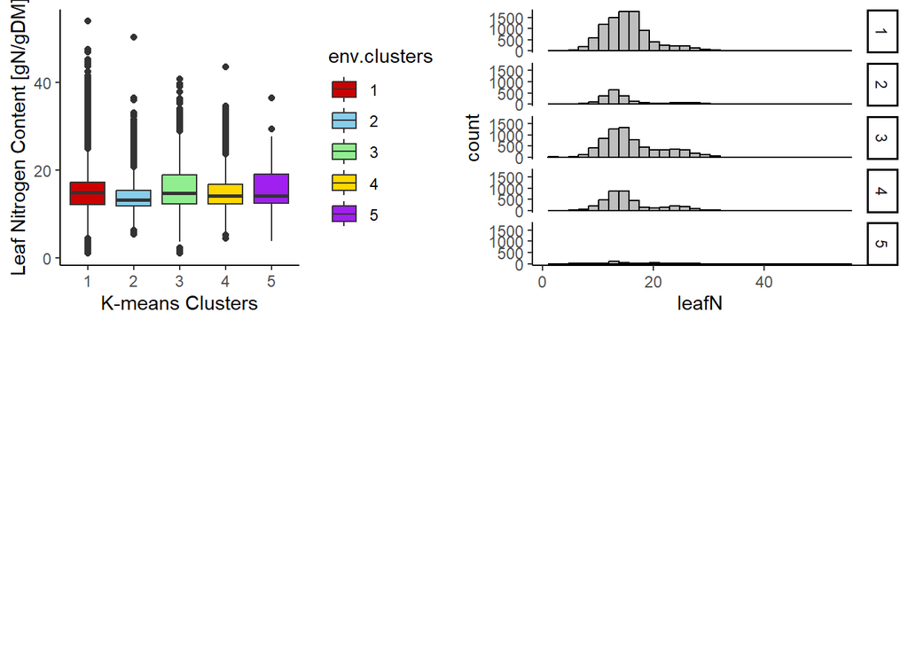

Fig. 5: Distribution of leafN data by environmental cluster.

**Environmental cross-validation model implementation as for 2.3:**

```r
# create folds based on clusters

group_folds_train.env <- purrr::map(
  seq(length(unique(dfs$env.clusters))),
  ~ {
    dfs |>
      select(env.clusters) |>
      mutate(idx = 1:n()) |>
      filter(env.clusters != .) |>
      pull(idx)
  }
)

group_folds_test.env <- purrr::map(
  seq(length(unique(dfs$env.clusters))),
  ~ {
    dfs |>
      select(env.clusters) |>
      mutate(idx = 1:n()) |>
      filter(env.clusters == .) |>
      pull(idx)
  }
)
```

```r
# we use the function defined above again:

# apply function on each custom fold and collect validation results in a nice data frame
out.env <- purrr::map2_dfr(
  group_folds_train.env,
  group_folds_test.env,
  ~train_test_by_fold(dfs,.x,.y)
) |>
  mutate(test_fold = 1:5)

out.env
```

```
## # A tibble: 5 × 3
##     rsq  rmse test_fold
##   <dbl> <dbl>     <int>
## 1 0.469  3.56         1
## 2 0.601  3.22         2
## 3 0.650  3.26         3
## 4 0.649  2.97         4
## 5 0.597  3.12         5
```

*2) Compare the results of the environmental cross-validation to the results of the random and the spatial cross-validation and discuss reasons for why you observe a difference in the cross-validation metrics (if you do).*

The Rsquared and RMSE values are much more consistent for the environmental cross-validation model than what we observed for spatial cross-validation (see 2.3). The Rsquared is generally higher compared to spatial cross-validation and the RMSE lower, indicating a higher accuracy and improved model fit. The improved model accuracy and fit compared to spatial cross-validation can be attributed to the clustering in environmental space, which here describe leaf nitrogen content better than spatial clusters.

The random cross-validation still yields better results than the environmental cross-validation with a higher Rsquared and lower RMSE value. Similarly to the explanation in 2.3.5, this can be attributed to the different methodologies behind the methods, where random forest splits the data into random fits and only assesses the prediction skill within those skills whereas the custom cross-validation withholds validation data that was not included in training.

*Reference:* Ludwig et al. (2023) Assessing and improving the transferability of current global spatial prediction models, *Global Ecology and Biogeography*, 32:356–368.